# Coursework Report

*N* removed NAs: 3

*N* removed typo: 1

*N* removed <18: 12

*N* total clean: 134

| Group | *N* | *M*<sub>age</sub> | *M*<sub>rating</sub> |
| --- | --- | --- | --- |
| Control | 72 | 20.57 | 7.18 |
| Experim | 62 | 21.16 | 5.80 |

**Main analysis results**

*t*(132) = 10.58, *p* < .001

[interactive chart not shown]

[figure not shown]

[interactive chart not shown]

# Coursework Report

Analysing Data, Spring 2020

# Methods

## Participants

Table 1 *Descriptive statistics by Condition*

[output not shown]

## Design

The conceptual hypothesis of this study is ‘colour influence’s attractiveness’. Colour is the independent/factor variable in this experiment. This has two levels which are the condition a participant is put into, either red, the experimental condition, or white, the control condition. The participants would see the same photo of a moderately attractive man, but in the red, experimental, condition they would see the photo with a red colour frame, and in the white, control, condition they would see a photo with a white coloured frame. The predictor is what is being manipulated. After they saw the photos, they were asked to rate the mans attractiveness, which is the continuous/rating variable. The participants where asked 3 questions each about each man presented in the photo, the questions being “How attractive do you think this person is?”, “How pleasant is this person to look at?” and “If I were to meet the person in this picture face to face, I would think he is attractive?”. These were all rated on 9-point scale of 1-9, where a higher score indicated a more positive perception of attractiveness. The final step, after all this data has been collected, was to do conduct an independent measures t-test to see whether there is a significant difference between results from the experimental condition and the control condition. From all this we get the main hypothesis of ‘the colour red will increase women’s attraction to a man by increasing their perceptions of the man’s status’. With the null hypothesis being ‘there will be no significant difference in ratings of attractiveness between the experimental condition and the control condition’.

# Results

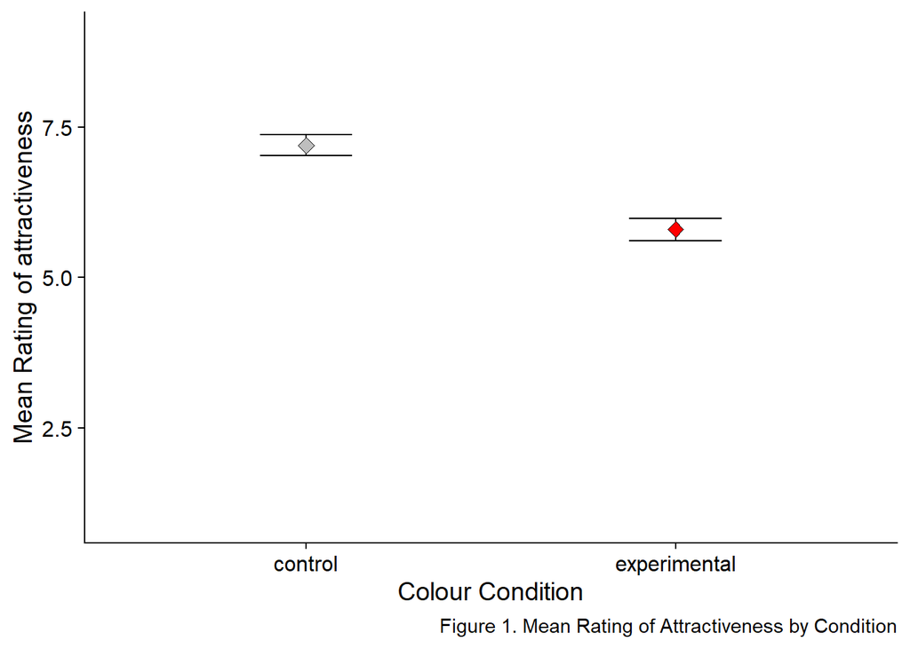

# Discussion

We conducted this study to test for the red effect on attractiveness. Contrary to what we expected our results showed that the white condition increased women’s perceptions of attractiveness of a man significantly more than the red condition. As of this, we can offer great insight into the theory of colour effecting women’s perception of attractiveness of men, which was originally raised by Elliot in 2010.

The results from our study completely contrasted those of the original study by Elliot (2010), with the original study providing results which showed a red colour background made a man appear significantly more attractive than a black and white coloured background. Both studies successfully show that colour does effect a women’s perception of attractiveness of a man, however one suggests red makes a man be more attractive compared to white, and the other suggets the opposite. Therefore, we can imply that colour does effect the attractiveness of a man to a women, but from comparing the studies, the fact they contrast each other means we cannot say anything about the red effect making a man appear more attractive to a women.

A study conducted on Mandrills showed that the redness of a male Mandrill’s face increases alongside the increase of his status and rank, and vice versa (Little et al, 2011). Then there is proof that female mandrills present themselves more sexually towards, and groom more often, males with brighter and more red noses(Setchel, 2005). This study also contradicts the results of the study we conducted. We can again imply from both studies that colour does make a difference in female attraction towards men, but we cannot say it is the same across the animal kingdom due to the studies having different colours creating a higher perceived attraction. We can also imply that the red effect is valid among mandrills, but we cannot say the same for humans.

Another study also attempted to replicate the findings of Elliot’s study on red effecting attractiveness (2010). The replication study by Peperkoorn (2016), involved them conducting 3 experiments comparing the colour white, red, and black on attractiveness and the results found no evidence to support the red effect. Our results agree with this as they found no evidence to support the red effect theory, and in fact contrasted it. For the effect under investigation, we can say that it is by far still a theory and there needs to be a lot more research to see if the effect is true or not, however, we still cannot say for certain it is not true due to other studies providing evidence which supports the red effect.

Ultimately, the analysis of our results shows the red effect not to be real. The original study that supports it has extremely low validity. Whereas 2 repeat studies, including our own, don’t find any evidence to support the red effect and have much higher validities.

Further research on the red effect is vitally important due to the implications it may have on Fashion, advertising and sales where the value of the red effect could be extremely valuable. We can suggest that maybe the red effect was true in 2011, but my study being conducted in 2020, and Peperkorn’s in 2016 both disprove the theory. It could be said that maybe it is outdated due to women gaining more rights and opportunities, therefore able to gain just as high status’ as men in the world now (Banyard, 2010). A way to test this in the future could be to get a group of older women, who are used to traditional ways of men being more high in status (Banyard, 2010), and a group of younger women, who have grown up in a society where women have more rights and opportunities (Banyard, 2010) to all analyse the same photo’s of moderately attractive men using slightly different methods to previous studies and see if there is a significant difference. They would all see the same 2 photos, one image of a man with red coloured background and the other being a black and white photo of a different man. Then collect the results in the same way as our previous study through a rating scale and the same 3 questions asked, and compare results of the 2 groups. If the results are found to be significant, factors of advertising, fashion and sales can be tailored to different age groups to improve marketing.

To conclude, the study we carried out provides evidence which contrasts the red effect theory. Therefore through analyses of the study we can say that the red effect is unlikelly to be true, but we cannot say for certain and further research is needed on the effect in order for a definitive answer on whether the red effect is true or not and how useful it can be.

# References

Banyard, K. (2010). The equality illusion: The truth about women and men today. Faber & Faber.

Elliot, A. J., Kayser, D. N., Greitemeyer, T., Lichtenfeld, S., Gramzow, R. H., Maier, M. A., & Liu, H. (2010). Red, rank, and romance in women viewing men. Journal of Experimental Psychology: General, 139(3), 399–417.

Little, A. C., Jones, B. C., & DeBruine, L. M. (2011). Facial attractiveness: evolutionary based research. Philosophical Transactions of the Royal Society B: Biological Sciences, 366(1571), 1638-1659.

Peperkoorn, L. S., Roberts, S. C., & Pollet, T. V. (2016). Revisiting the red effect on attractiveness and sexual receptivity: No effect of the color red on human mate preferences. Evolutionary Psychology, 14(4), 1474704916673841.

Setchell J. M. 2005. Do female mandrills prefer brightly colored males? Int. J. Primatol. 26, 715–735